# EDS 223: assignment 4

{Annie Adams}

2022-11-16

## Background

Marine aquaculture has the potential to play an important role in the global food supply as a more sustainable protein option than land-based meat production.[^1] [Gentry et al.](https://www.nature.com/articles/s41559-017-0257-9) mapped the potential for marine aquaculture globally based on multiple constraints, including ship traffic, dissolved oxygen, bottom depth .[^2]

## Overview

Knowing that marine aquaculture can be a sustainable option over land based meat products, we are going to map Exclusive Economic Zones for different species, based on two conditions each species relies on for optimal growth: Sea surface temperature and depth. We will first focus on mapping suitable sites for Oysters on the West Coast of the US. Upon mapping sites for oysters, we will create a reproducible function that can map EEZs on the West Coast, when provided a species and their ideal depth and seas surface temperature range.

## Data

#### Sea Surface Temperature

We will use average annual sea surface temperature (SST) from the years 2008 to 2012 to characterize the average sea surface temperature within the region. The data we are working with was originally generated from [NOAA’s 5km Daily Global Satellite Sea Surface Temperature Anomaly v3.1](https://coralreefwatch.noaa.gov/product/5km/index_5km_ssta.php).

#### Bathymetry

To characterize the depth of the ocean we will use the [General Bathymetric Chart of the Oceans (GEBCO)](https://www.gebco.net/data_and_products/gridded_bathymetry_data/#area).[^3]

#### Exclusive Economic Zones

We will be designating maritime boundaries using Exclusive Economic Zones off of the west coast of US from [Marineregions.org](https://www.marineregions.org/eez.php).

## Analysis

#### Load necessary packages and data

```r
#load in necessary packages
library(sf)
library(terra)
library(here)
library(dplyr)
library(rpart)
library(rpart.plot)
library(tmap)
library(tidyverse)
#library(OpenStreetMap)
library(tmaptools)
library(maptiles)
rm(list = ls())

here::i_am("./eez-suitability.Rmd")
setwd(here())
```

```r
#read in west coast shapefile
wc <- st_read('./data/wc_regions_clean.shp')

#make raster stack of 2008 to 2021 sea surface temperature rasters
filelist <- list.files("./data/sst/", full.names = TRUE)
sst <- rast(filelist)

#read in bathymetry raster
bathymetry <- rast("./data/depth.tif")
```

#### Prepare Data

Since we will be mapping our datasets, we need to first and foremost make sure they all have matching crs’.

```r
## check crs
st_crs(wc) #4326
```

```
## Coordinate Reference System:
##   User input: WGS 84
##   wkt:
## GEOGCRS["WGS 84",
##     DATUM["World Geodetic System 1984",
##         ELLIPSOID["WGS 84",6378137,298.257223563,
##             LENGTHUNIT["metre",1]]],
##     PRIMEM["Greenwich",0,
##         ANGLEUNIT["degree",0.0174532925199433]],
##     CS[ellipsoidal,2],
##         AXIS["latitude",north,
##             ORDER[1],
##             ANGLEUNIT["degree",0.0174532925199433]],
##         AXIS["longitude",east,
##             ORDER[2],
##             ANGLEUNIT["degree",0.0174532925199433]],
##     ID["EPSG",4326]]
```

```r
st_crs(sst) #9122
```

```
## Coordinate Reference System:
##   User input: WGS 84
##   wkt:
## GEOGCRS["WGS 84",
##     DATUM["unknown",
##         ELLIPSOID["WGS84",6378137,298.257223563,
##             LENGTHUNIT["metre",1,
##                 ID["EPSG",9001]]]],
##     PRIMEM["Greenwich",0,
##         ANGLEUNIT["degree",0.0174532925199433,
##             ID["EPSG",9122]]],
##     CS[ellipsoidal,2],
##         AXIS["latitude",north,
##             ORDER[1],
##             ANGLEUNIT["degree",0.0174532925199433,
##                 ID["EPSG",9122]]],
##         AXIS["longitude",east,
##             ORDER[2],
##             ANGLEUNIT["degree",0.0174532925199433,
##                 ID["EPSG",9122]]]]
```

```r
st_crs(bathymetry) #4326
```

```
## Coordinate Reference System:
##   User input: WGS 84
##   wkt:
## GEOGCRS["WGS 84",
##     ENSEMBLE["World Geodetic System 1984 ensemble",
##         MEMBER["World Geodetic System 1984 (Transit)"],
##         MEMBER["World Geodetic System 1984 (G730)"],
##         MEMBER["World Geodetic System 1984 (G873)"],
##         MEMBER["World Geodetic System 1984 (G1150)"],
##         MEMBER["World Geodetic System 1984 (G1674)"],
##         MEMBER["World Geodetic System 1984 (G1762)"],
##         MEMBER["World Geodetic System 1984 (G2139)"],
##         ELLIPSOID["WGS 84",6378137,298.257223563,
##             LENGTHUNIT["metre",1]],
##         ENSEMBLEACCURACY[2.0]],
##     PRIMEM["Greenwich",0,
##         ANGLEUNIT["degree",0.0174532925199433]],
##     CS[ellipsoidal,2],
##         AXIS["geodetic latitude (Lat)",north,
##             ORDER[1],
##             ANGLEUNIT["degree",0.0174532925199433]],
##         AXIS["geodetic longitude (Lon)",east,
##             ORDER[2],
##             ANGLEUNIT["degree",0.0174532925199433]],
##     USAGE[
##         SCOPE["Horizontal component of 3D system."],
##         AREA["World."],
##         BBOX[-90,-180,90,180]],
##     ID["EPSG",4326]]
```

```r
#transofrm sst raster to 4326
sst <- project(sst, crs(wc))
```

#### Process data

We will use the mean seasurface temperature for our analysis. Because our data is in Kelvin, we first need to convert it to celcius. We will then crop our depth raster to the extent of the seasurface temperature data. Next, we need to process the SST and depth data so that they can be combined. In this case the SST and depth data have slightly different resolutions, extents, and positions. We don’t want to change the underlying depth data, so we will need to resample to match the SST data using the nearest neighbor approach.

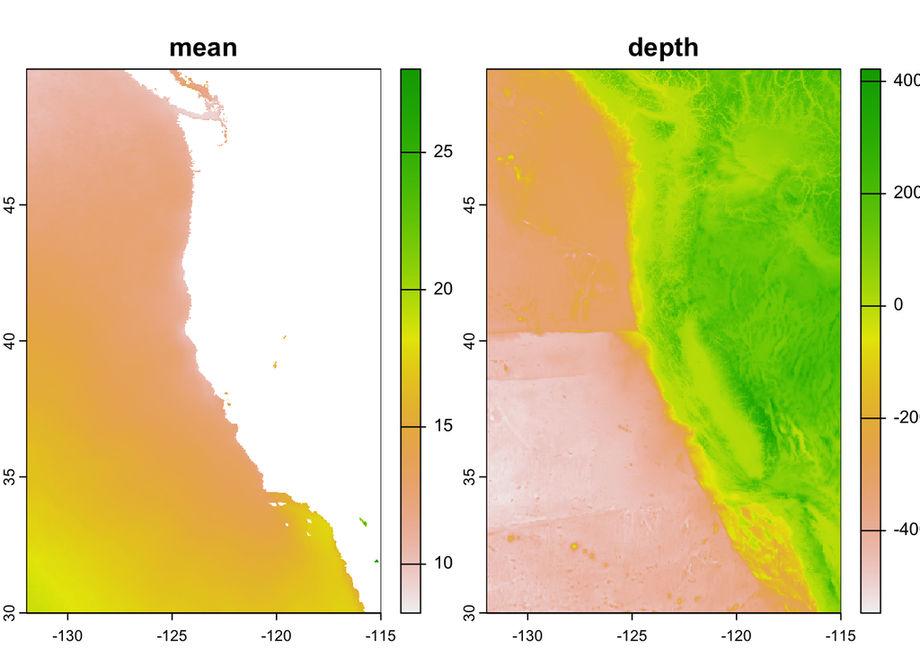

```r
sst_mean <-  mean(sst) # find mean of raster data
sst_mean_celsius <- sst_mean - 273.15 # convert data from fahrenheit to celsius
sst_depth_extent <- crop(bathymetry, sst_mean_celsius) #crop depth data to extent of seasurface temp data

sst_depth_extent_res <- resample(x =sst_depth_extent, # resample depth data to match resolution of the SST data using nearest neighbor method
                               y = sst_mean_celsius,
                               method = "near")


# check that depth and SST match in resolution , extent, and crs
st_crs(bathymetry) == st_crs(sst_depth_extent_res)
res(bathymetry) == res(sst_depth_extent_res)
ext(bathymetry) == ext(sst_depth_extent_res)

#check to see if rasters can be stacked
sst_depth_stack <- rast(list(sst_mean_celsius, sst_depth_extent_res)) # stack rasters
plot(sst_depth_stack) # plot the stacked rasters
```

#### Find suitable locations

In order to find suitable locations for marine aquaculture, we’ll need to find locations that are suitable in terms of both SST and depth. Based on previous research, we know that oysters needs the following conditions for optimal growth:

- sea surface temperature: 11-30°C
- depth: 0-70 meters below sea level

We will now find suitable locations based on these metrics. We will reclassify SST and depth to match locations that are suitable for oysters.

```r
#Reminder: ideal sea surface and depth temperatures for oysters: sea surface temperature: 11-30&deg celsius, depth: 0-70 meters below sea level

rcl_sst = matrix(c(11, 30, 1,  # reclassification matrix to match optimal oyster seasurface temperature
               -Inf, 11, NA,
               30, Inf, NA), ncol = 3,
             byrow = TRUE)

sst_mean_reclass = classify(sst_mean_celsius, rcl = rcl_sst) # apply reclassification to sst_mean


rcl_depth = matrix(c(-70,0,  1,    # reclassification matrix to match optimal oyster depth
               -Inf, -70, NA,
               0, Inf, NA), ncol = 3,
             byrow = TRUE)


depth_reclass = classify(sst_depth_extent_res, rcl = rcl_depth) # apply reclassification to depth


# crop sst and depth to reclassified standards
sst_oyster <- crop(sst_mean_celsius, sst_mean_reclass)
depth_oyster <- mask(sst_depth_extent_res, depth_reclass)


#combine the two rasters
sst_depth_oyster <- rast(list(sst_oyster, depth_oyster))

#use lapp to multiply cell values
rast_mult_func <- function(x,y){return(x*y)}
oyster_locations <- lapp(sst_depth_oyster, fun=rast_mult_func )
```

#### Determine the most suitable EEZ

Now that we have reclassified the data to match our qualifications for suitable oyster EEZs, we will find the total area of EEZ’s available on the West Coast. We then can find the area present in each of our five regions, to ultimately get the percentage of each region that is suitable.

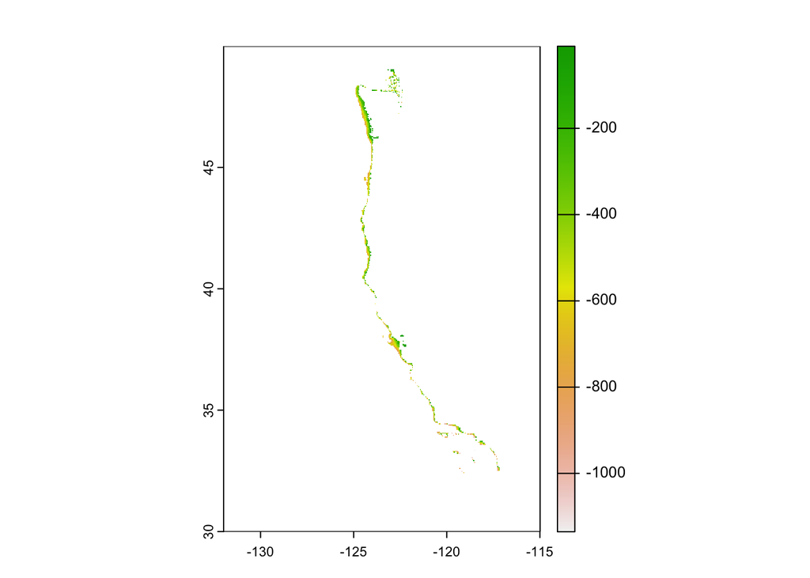

```r
#select suitable cells within West Coast EEZs
oyster_west <-mask(oyster_locations, wc)
plot(oyster_west)
```

```r
#plot(oyster_locations)  check to see if plots look different
#plot(oyster_west)


#rasterize eez data
wc_rast <- rasterize(wc, oyster_west, field ="rgn")

#find area of grid cells
wc_area <- cellSize(oyster_west, mask = TRUE, unit = "km", transform = TRUE)
#print(wc_area)

#sum up area of grid cells
area <- zonal(wc_area, wc_rast, fun = "sum", na.rm = TRUE)

#join west coast and area of west coast area to get area of individual grid cells and total area, calculate percentage
eez_west <- left_join(wc, area) %>%
  mutate(suitable_perc = (area/ area_km2)* 100 )



zone_percentage <- eez_west %>% select(rgn, area,area_km2, suitable_perc) %>%  rename("Region" = rgn, "total_area" = area_km2, "Suitable_Percentage" = suitable_perc) %>% st_drop_geometry()
zone_percentage <-data.frame(zone_percentage)
print(zone_percentage)
```

```
##                Region     area total_area Suitable_Percentage
## 1              Oregon 3487.997  179994.06            1.937840
## 2 Northern California 2735.930  164378.81            1.664406
## 3  Central California 4221.758  202738.33            2.082368
## 4 Southern California 3508.187  206860.78            1.695917
## 5          Washington 6331.702   66898.31            9.464666
```

#### Visualize EEZ Suitability

Now that we have results, we will present them! We will map our suitable percentages for oysters onto a West Coast Map. We will create two maps: one for total suitable area for each region, and one for the percent suitable area for each region.

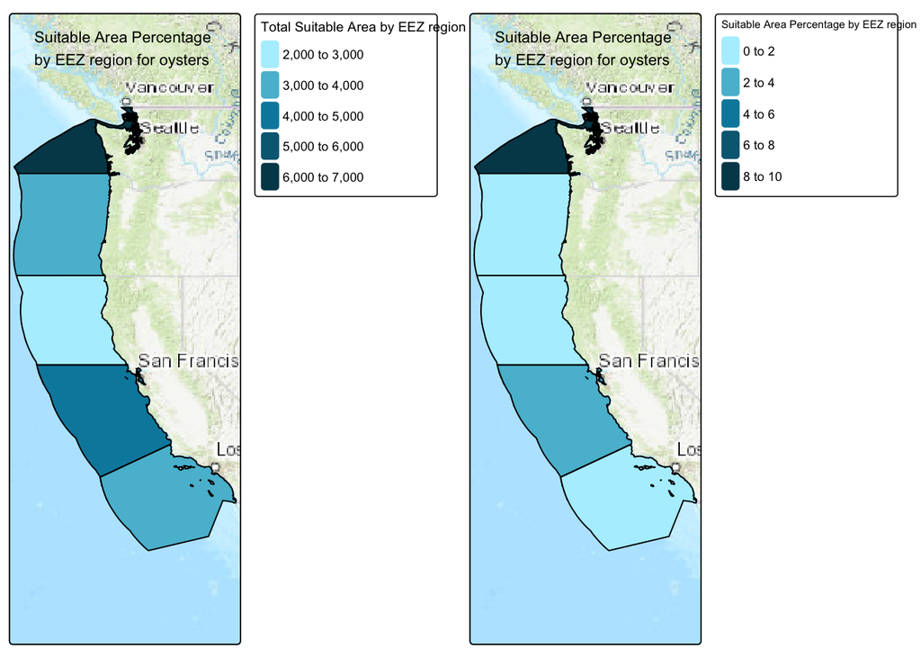

```r
#plot area percentage map
oyster_percentage <- tm_shape(eez_west) +
  tm_fill("suitable_perc", title = "Suitable Area Percentage by EEZ region",
              palette= (c("#b1effe", #a1ceff", "#4fdcff", "#00acfc",
                          "#0089ab", "#004759"))) +
    tm_layout( title = paste0("Suitable Area Percentage \nby EEZ region for oysters"), legend.title.size = .60, title.size = 12, #adjust layout properties
             main.title.position = "center", legend.width = 12,legend.height = 12, main.title.fontface = "bold")+
                            tm_borders(col = "black")+
tm_basemap("Esri.WorldTopoMap") # add basemap

#plot total area map
oyster_sum<- tm_shape(eez_west) +
  tm_fill("area", title = "Total Suitable Area by EEZ region",
              palette= (c("#b1effe", #a1ceff", "#4fdcff", "#00acfc",
                          "#0089ab", "#004759"))) +
  tm_layout( title = paste0("Suitable Area Percentage \nby EEZ region for oysters"), legend.title.size = .75, title.size = 12, # adjust layout properties
             main.title.position = "center", legend.width = 12,legend.height = 12, main.title.fontface = "bold",)+
                            tm_borders(col = "black")+
  tm_basemap("Esri.WorldTopoMap") # add basemap

tmap_arrange(oyster_sum, oyster_percentage) # plot two plots next to each other
```

#### Maps for any species!

We looked at oysters specifically, but we can extend our analysis to produce output for any given species that is apart of marine aquaculture. Let’s create a function that accepts a min temperature, max temperature, min depth, max depth, and species name. This function will reclassify the sea surface and depth data based on the given parameters, and then create two maps similar to the ones above - one for total suitable area and one for percent suitable area.

```r
suitable_func <- function(temp_min, temp_max, depth_min, depth_max,species){ # create function with parameteres of min and max depth and range



rcl_sst = matrix(c( # reclassification for sst using parameters
               -Inf, temp_min, NA,
               temp_min, temp_max, 1,
               temp_max, Inf, NA), ncol = 3,
             byrow = TRUE)

sst_mean_reclass = classify(sst_mean_celsius, rcl = rcl_sst) # apply reclassification


rcl_depth = matrix(c(  # reclassification for depth using parameters
               -Inf, depth_max, NA,
               depth_max,depth_min,  1,
               depth_min, Inf, NA), ncol = 3,
             byrow = TRUE)


depth_reclass = classify(sst_depth_extent_res, rcl = rcl_depth) # apply reclassification


# crop sst and depth to reclassified standards
sst_oyster <- crop(sst_mean_celsius, sst_mean_reclass)
depth_oyster <- mask(sst_depth_extent_res, depth_reclass)


#combine the two rasters
sst_depth_oyster <- rast(list(sst_oyster, depth_oyster))

#use lapp to multiply cell values
rast_mult_func <- function(x,y){return(x*y)}
oyster_locations <- lapp(sst_depth_oyster, fun=rast_mult_func )




#select suitable cells within West Coast EEZs
oyster_west <-mask(oyster_locations, wc)



#rasterize eez data
wc_rast <- rasterize(wc, oyster_west, field ="rgn")

#find area of grid cells
wc_area <- cellSize(oyster_west, mask = TRUE, unit = "km", transform = TRUE)

#sum area of grid cells
area <- zonal(wc_area, wc_rast, fun = "sum", na.rm = TRUE)

#join west coast and area of west coast area to get area of individual grid cells and total area, calculate percentage
eez_west <- left_join(wc, area) %>%
  mutate(suitable_perc = (area/ area_km2)* 100 )


#plot area percentage map
percent_map <- tm_shape(eez_west) +
  tm_fill("suitable_perc", title = "Suitable Area Percentage by EEZ region",
              palette= (c("#b1effe", "#a1ceff", "#4fdcff", "#00acfc",
                          "#0089ab", "#004759"))) +
                            tm_borders(col = "black")+
  tm_layout( title = paste0("Suitable Area Percentage \nby EEZ region for", species), legend.title.size = .60, title.size = 14, #adjust layout properties
             main.title.position = "center", legend.width = 12,legend.height = 12, main.title.fontface = "bold")+
  tm_basemap("Esri.WorldTopoMap") # add basemap

#plot area total map
total_map <- tm_shape(eez_west) +
  tm_fill("area", title = "Total Suitable Area by EEZ region",
              palette= (c("#b1effe", "#a1ceff", "#4fdcff", "#00acfc",
                          "#0089ab", "#004759"))) +
                            tm_borders(col = "black")+
  tm_layout( title = paste0("Suitable Area Percentage \nby EEZ region for", species), legend.title.size = .75, title.size = 14, # adjust layout properties
             main.title.position = "right", legend.width = 12,legend.height = 12, main.title.fontface = "bold",)+
  tm_basemap("Esri.WorldTopoMap")  # add basemap

tmap_arrange(percent_map, total_map) # plot two maps next to each other

}
```

Let’s test our reproducible function out with rainbow trout! Rainbow trout are accustomed to water temperatures between 10 and 24 degrees celsius and depths between 0 and 200 meters.

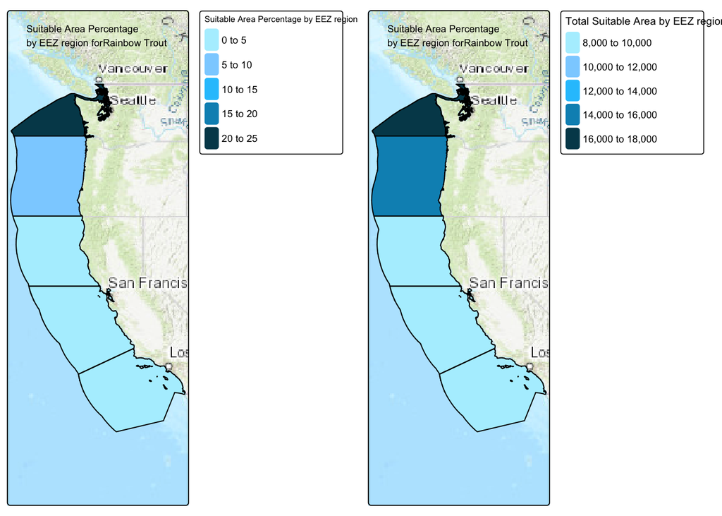

```r
suitable_func(10, 24, 0, -200,   "Rainbow Trout ")
```

[^1]: Hall, S. J., Delaporte, A., Phillips, M. J., Beveridge, M. & O’Keefe, M. Blue Frontiers: Managing the Environmental Costs of Aquaculture (The WorldFish Center, Penang, Malaysia, 2011).
[^2]: Gentry, R. R., Froehlich, H. E., Grimm, D., Kareiva, P., Parke, M., Rust, M., Gaines, S. D., & Halpern, B. S. Mapping the global potential for marine aquaculture. *Nature Ecology & Evolution*, 1, 1317-1324 (2017).
[^3]: GEBCO Compilation Group (2022) GEBCO_2022 Grid (doi:10.5285/e0f0bb80-ab44-2739-e053-6c86abc0289c).